# Data Visualisation - Road Casualties by Severity

The dataset is analysed to form insightful research questions and thus prepare the dataset accordingly. Following the pre-processing, a univariate analysis and visualisations have been done. Lastly, in light of research questions, multivariate analysis has been done. It has been observed that some geographical locations, time periods and demographic groups are more prone to casualties.

Following questions were asked throughout the project:

- Are there specific locations prone to casualties?
- Are there specific time periods prone to casualties?
- Are there specific demographic groups prone to casualties?

```python
%matplotlib inline
import numpy as np
import pandas as pd
from pandas.api.types import CategoricalDtype
import matplotlib
import matplotlib.pyplot as plt
import matplotlib.ticker as ticker
import seaborn as sns
import plotly
plotly.tools.set_credentials_file(username='gorhan95', api_key='zWMc4fMq0PvxyEZhN2XU')
import cufflinks as cf
import plotly.plotly as py
import plotly.graph_objs as go
```

Dataset was acquired through London Datastore website (https://data.london.gov.uk/dataset) under the name of ‘Road Casualties by Severity’, which is published by Department for Transport. The Road Casualties by Severity data (https://data.london.gov.uk/dataset/road-casualties-severity-borough), was chosen, as it was published by a government office which makes the data trustworthy and valid. The data is collected through local authority incident records and aggregated by Department for Transport office.

```python
#Read casualty data
df = pd.read_csv('london-ksi-only-since2010.csv')
df.head(2)
```

|  | Easting | Northing | Severity of casualty | Casualty Class | Sex | Age | Date | Day of week | Hour of day | Local authority | Vehicle type | Pedestrian Locality |
| --- | --- | --- | --- | --- | --- | --- | --- | --- | --- | --- | --- | --- |
| 0 | 526940 | 177890 | Serious | Pedestrian | Male | 14 | 15/01/2010 | Friday | 16 | Kensington and Chelsea | Motorcycle over 125cc and up to 500cc | Not a pedestrian |
| 1 | 527790 | 179400 | Serious | Pedestrian | Female | 46 | 13/01/2010 | Wednesday | 17 | Kensington and Chelsea | Taxi/Private hire car | Crossing on ped. crossing facility |

Acquired dataset was a relatively tidy and clean dataset which I believe is due to the fact that data is coming from official records. In terms of tidying and pre-processing the data, following steps were taken:

1. Column names are re-assigned for an easier coding purpose.
2. The ‘Pedestrian_locality’ column is dropped since it was containing inconsistent information with rest of the dataset. Even though the casualty class was categorized as pedestrian, ‘Pedestrian_locality’ variable was categorized as ‘not pedestrian’ which gives the impression that unknown locality is labelled as ‘not pedestrian’. In addition,more than 85% of the casualties labelled as ‘not pedestrian’. Therefore, it is concluded that analysing this variable will be misleading and thus, it is dropped.
3. Rows containing incident records with ‘unknown’ age variable is dropped in order univariate analysis to have consistency in itself. There were 681 casualty records with unknown age variable.
4. No ‘NA’ filling is done due to the fact that there were no missing values.
5. ‘Vehicle_type’ variable had 25 different categories such as: Motorcycle over 500cc, Motorcycle 50cc and under, etc. Since the project doesn’t concern this amount of detail, for simplicity, categories aggregated into 11 such as: car, motorcycle, minibus, etc.
6. Variable types are re-assigned in order to make accurate visualisations.

```python
##DATA PRE-PROCESSING
#Rename the columns in order to code easier
df.columns=['Easting','Northing','Severity_of_casualty','Casualty_class','Sex','Age','Date','Day_of_week',
            'Hour_of_day','Local_authority','Vehicle_type','Pedestrian_locality']

#Drop the Pedestrian_locality column because of the inconsistency
df=df.drop(['Pedestrian_locality'],axis=1)

#Drop the rows with unknown Age variables in order to maintain consistency in univariate analysis
df = df[(df.Age != 'unknown')]

#Check total number of casualties and NA values
casualties = df.shape[0]
print("Total number of serious or fatal casualties between 2010-2014 (unknowns excluded): {}".format(casualties))
display(df.isna().sum())
```

```
Total number of serious or fatal casualties between 2010-2014 (unknowns excluded): 12525
```

```
Easting                 0
Northing                0
Severity_of_casualty    0
Casualty_class          0
Sex                     0
Age                     0
Date                    0
Day_of_week             0
Hour_of_day             0
Local_authority         0
Vehicle_type            0
dtype: int64
```

```python
#Group vehicle types to avoid messy graphs
df1=df.copy()
df1['Vehicle_type']=np.where(df1['Vehicle_type'] =='Car', 'Car', df1['Vehicle_type'])
df1['Vehicle_type']=np.where(df1['Vehicle_type'] =='Car (from 2005)', 'Car', df1['Vehicle_type'])
df1['Vehicle_type']=np.where(df1['Vehicle_type'] =='Motorcycle over 125cc and up to 500cc', 'Motorcycle', df1['Vehicle_type'])
df1['Vehicle_type']=np.where(df1['Vehicle_type'] =='Motor cycle 125cc and under', 'Motorcycle', df1['Vehicle_type'])
df1['Vehicle_type']=np.where(df1['Vehicle_type'] =='Motorcycle over 500cc', 'Motorcycle', df1['Vehicle_type'])
df1['Vehicle_type']=np.where(df1['Vehicle_type'] =='Motorcycle 50cc and under', 'Motorcycle', df1['Vehicle_type'])
df1['Vehicle_type']=np.where(df1['Vehicle_type'] =='Motorcycle over 125cc and up to 500cc (from 2005)', 'Motorcycle', df1['Vehicle_type'])
df1['Vehicle_type']=np.where(df1['Vehicle_type'] =='M/cycle over 50 and up to 125cc (from 1999)', 'Motorcycle', df1['Vehicle_type'])
df1['Vehicle_type']=np.where(df1['Vehicle_type'] =='Motorcycle over 500cc (from 2005)', 'Motorcycle', df1['Vehicle_type'])
df1['Vehicle_type']=np.where(df1['Vehicle_type'] =='Taxi/Private hire car', 'Taxi/Private hire car', df1['Vehicle_type'])
df1['Vehicle_type']=np.where(df1['Vehicle_type'] =='Taxi / Private hire car (from 2005)', 'Taxi/Private hire car', df1['Vehicle_type'])
df1['Vehicle_type']=np.where(df1['Vehicle_type'] =='Goods 3.5 tonnes maximum gross weight or under', 'Goods', df1['Vehicle_type'])
df1['Vehicle_type']=np.where(df1['Vehicle_type'] =='Goods 7.5 tonnes mgw and over', 'Goods', df1['Vehicle_type'])
df1['Vehicle_type']=np.where(df1['Vehicle_type'] =='Goods over 3.5t. and under 7.5t. (from 1999)', 'Goods', df1['Vehicle_type'])
df1['Vehicle_type']=np.where(df1['Vehicle_type'] =='Goods 7.5 tonnes mgw and over (from 1999)', 'Goods', df1['Vehicle_type'])
df1['Vehicle_type']=np.where(df1['Vehicle_type'] =='Goods over 3.5t and under 7.5t mgw', 'Goods', df1['Vehicle_type'])
df1['Vehicle_type']=np.where(df1['Vehicle_type'] =='Van / Goods 3.5 tonnes mgw or under', 'Goods', df1['Vehicle_type'])
df1['Vehicle_type']=np.where(df1['Vehicle_type'] =='Minibus (8-16 passenger seats)', 'Minibus', df1['Vehicle_type'])
df1['Vehicle_type']=np.where(df1['Vehicle_type'] =='Minibus (8 - 16 passenger seats) (from 1999)', 'Minibus', df1['Vehicle_type'])
df1.head(2)
```

|  | Easting | Northing | Severity_of_casualty | Casualty_class | Sex | Age | Date | Day_of_week | Hour_of_day | Local_authority | Vehicle_type |
| --- | --- | --- | --- | --- | --- | --- | --- | --- | --- | --- | --- |
| 0 | 526940 | 177890 | Serious | Pedestrian | Male | 14 | 15/01/2010 | Friday | 16 | Kensington and Chelsea | Motorcycle |
| 1 | 527790 | 179400 | Serious | Pedestrian | Female | 46 | 13/01/2010 | Wednesday | 17 | Kensington and Chelsea | Taxi/Private hire car |

```python
#Observe data types
df1.dtypes
```

```
Easting                  int64
Northing                 int64
Severity_of_casualty    object
Casualty_class          object
Sex                     object
Age                     object
Date                    object
Day_of_week             object
Hour_of_day              int64
Local_authority         object
Vehicle_type            object
dtype: object
```

```python
#Setting data types
for i in df1.columns:
    if i=='Severity_of_casualty': #setting an ordinal variable
        Severity= ['Serious','Fatal']
        df1[i] = df1[i].astype(CategoricalDtype(categories=Severity,ordered=True))
    elif i=='Day_of_week': #setting an ordinal variable
        Day=['Monday','Tuesday','Wednesday','Thursday','Friday','Saturday','Sunday']
        df1[i] = df1[i].astype(CategoricalDtype(categories=Day,ordered=True))
    elif i=='Age' or i=='Hour_of_day' or i=='Easting' or i=='Northing':
        df1[i] = df1[i].astype('int64')
    elif i=='Date':
        df1[i] = df1[i].astype('datetime64')
    else: #setting a nominal variable
        df1[i] = df1[i].astype('category')
df1.dtypes
```

```
Easting                          int64
Northing                         int64
Severity_of_casualty          category
Casualty_class                category
Sex                           category
Age                              int64
Date                    datetime64[ns]
Day_of_week                   category
Hour_of_day                      int64
Local_authority               category
Vehicle_type                  category
dtype: object
```

```python
header_list=['Severity_of_casualty','Casualty_class','Sex','Local_authority','Vehicle_type']

#In order to gain insight, see unique values and some descriptive statistics
for i in header_list:
    display('Variable name is: '+i)
    display(pd.unique(df1[i].values.ravel('K')))
    display(df1[i].describe())
```

```
'Variable name is: Severity_of_casualty'
```

```
array(['Serious', 'Fatal'], dtype=object)
```

```
count       12525
unique          2
top       Serious
freq        11844
Name: Severity_of_casualty, dtype: object
```

```
'Variable name is: Casualty_class'
```

```
array(['Pedestrian', 'Driver or rider', 'Passenger'], dtype=object)
```

```
count               12525
unique                  3
top       Driver or rider
freq                 6982
Name: Casualty_class, dtype: object
```

```
'Variable name is: Sex'
```

```
array(['Male', 'Female'], dtype=object)
```

```
count     12525
unique        2
top        Male
freq       8759
Name: Sex, dtype: object
```

```
'Variable name is: Local_authority'
```

```
array(['Kensington and Chelsea', 'Hammersmith and Fulham', 'Westminster',
       'City of London', 'Camden', 'Brent', 'Islington', 'Haringey',
       'Hackney', 'Tower Hamlets', 'Waltham Forest', 'Newham',
       'Redbridge', 'Havering', 'Barking and Dagenham', 'Lambeth',
       'Wandsworth', 'Croydon', 'Southwark', 'Lewisham', 'Greenwich',
       'Bromley', 'Harrow', 'Bexley', 'Barnet', 'Kingston-upon-Thames',
       'Richmond-upon-Thames', 'Hounslow', 'Enfield', 'Merton', 'Ealing',
       'Sutton', 'Hillingdon', 'Heathrow Airport'], dtype=object)
```

```
count           12525
unique             34
top       Westminster
freq              806
Name: Local_authority, dtype: object
```

```
'Variable name is: Vehicle_type'
```

```
array(['Motorcycle', 'Taxi/Private hire car', 'Car', 'Moped',
       'Pedal cycle', 'Goods', 'Bus or coach (17 or more pass seats)',
       'Other motor vehicle', 'Minibus', 'Other vehicle',
       'Ridden horse (from 1999)'], dtype=object)
```

```
count     12525
unique       11
top         Car
freq       4907
Name: Vehicle_type, dtype: object
```

```python
#Observe Date variable alone not to see all Date values
df1['Date'].describe()
```

```
count                   12525
unique                   1817
top       2010-03-11 00:00:00
freq                       21
first     2010-01-01 00:00:00
last      2014-12-31 00:00:00
Name: Date, dtype: object
```

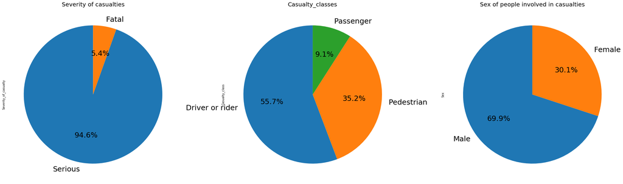

```python
#Create a figure
fig = plt.figure(figsize=(30,19))

#Add severity of casualty pie chart
fig.add_subplot(1,3,1)
p1 = df1['Severity_of_casualty'].value_counts()
ax = p1.plot.pie(autopct='%1.1f%%', startangle=90, textprops={'fontsize': 25})
ax.set_title("Severity of casualties",fontsize=20)

#Add casualty class pie chart
fig.add_subplot(1,3,2)
p3 = df1['Casualty_class'].value_counts()
ax = p3.plot.pie(autopct='%1.1f%%', startangle=90,textprops={'fontsize': 25})
ax.set_title("Casualty_classes",fontsize=20)

#Add sex pie chart
fig.add_subplot(1,3,3)
p2 = df1['Sex'].value_counts()
ax = p2.plot.pie(autopct='%1.1f%%', startangle=90, textprops={'fontsize': 25})
ax.set_title("Sex of people involved in casualties",fontsize=20)

#Save figure
plt.tight_layout()
plt.savefig('figgx',dpi=300)
plt.show()
```

```python
#Observe the median of an ordinal variable
df1['Severity_of_casualty'].cat.codes.median()
```

```
0.0
```

```python
#Plot an interactive histogram
df1['Age'].iplot(kind='histogram', colors='rgb(175, 109, 242)', xTitle='Age',yTitle='Number of casualties',
          title='Age distribution of casualties')
```

[interactive chart not shown]

```python
#Observe Age statistics
df1['Age'].describe()
```

```
count    12525.000000
mean        36.869381
std         18.499278
min          0.000000
25%         24.000000
50%         33.000000
75%         47.000000
max         99.000000
Name: Age, dtype: float64
```

```python
#Plot an interactive bar chart
df1['Day_of_week'].value_counts().iplot(kind='bar',colors='rgb(135, 209, 108)', xTitle='Day',yTitle='Number of casualty',
             title='Number of casualties by Day_of_week')
```

[interactive chart not shown]

```python
#Plot an interactive histogram
df1['Hour_of_day'].iplot(kind='histogram',colors='rgb(81, 197, 247)', xTitle='Hour',yTitle='Number of casualties',
          title='Casualty frequency by Hour_of_day')
```

[interactive chart not shown]

```python
#Observe Hour_of_day statistics
df1['Hour_of_day'].describe()
```

```
count    12525.000000
mean        13.355210
std          5.871295
min          0.000000
25%          9.000000
50%         14.000000
75%         18.000000
max         23.000000
Name: Hour_of_day, dtype: float64
```

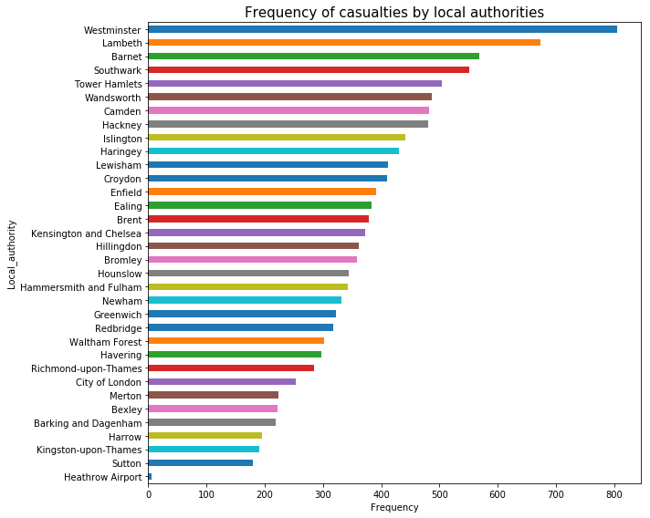

```python
#Create a figure
fig = plt.figure(figsize=(10,8))

#Plot the frequency bar graph for local authority variable
counts = df1['Local_authority'].value_counts()
ax = counts.plot.barh()
ax.invert_yaxis()
plt.title('Frequency of casualties by local authorities', fontsize = 15)
ax.set_xlabel('Frequency')
ax.set_ylabel('Local_authority')

#Customise and save figure
plt.tight_layout()
plt.savefig('fig1',dpi=300)
plt.show()
```

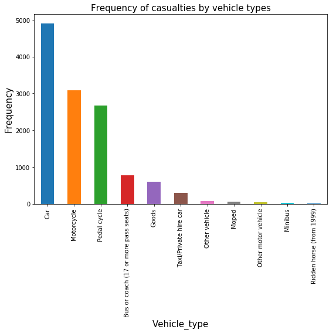

```python
#Create figure
fig = plt.figure(figsize=(8,8))

#Plot frequency of vehicle type variable
counts = df1['Vehicle_type'].value_counts()
ax = counts.plot.bar()
plt.title('Frequency of casualties by vehicle types', fontsize = 15)
ax.set_ylabel('Frequency',fontsize = 15)
ax.set_xlabel('Vehicle_type',fontsize = 15)

#Customise and save figure
plt.tight_layout()
plt.savefig('figg',dpi=300)
plt.show()
```

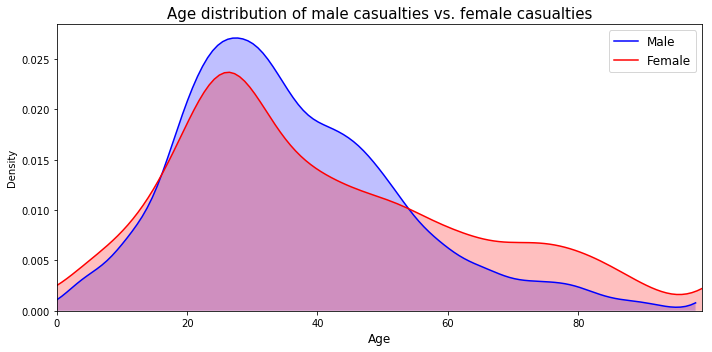

```python
#Create male dataframe
male_data = df1.loc[df1['Sex'] == 'Male']

#Create female dataframe
female_data = df1.loc[df1['Sex'] == 'Female']

#Plot density graph of age distribution of male casualties vs female casualties
ax = plt.figure(figsize=(10, 5))
sns.kdeplot(male_data.Age , color="blue", label="Male", shade = True, cut = 0)
sns.kdeplot(female_data.Age , color="red", label="Female", shade = True, cut = 0)
plt.title('Age distribution of male casualties vs. female casualties', fontsize = 15)
plt.xlabel('Age',fontsize = 12)
plt.ylabel('Density')

#Customise and save figure
plt.xlim(0,99)
plt.legend(fontsize= 12)
plt.tight_layout()
plt.savefig('fig2',dpi=300)
plt.show()
```

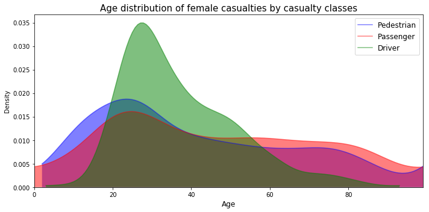

```python
#Creating female dataframe by casualty class
female_pedestrian = female_data.loc[female_data.Casualty_class == 'Pedestrian']
female_passenger = female_data.loc[female_data.Casualty_class == 'Passenger']
female_driver = female_data.loc[female_data.Casualty_class == 'Driver or rider']

#Plot density graph of age distribution of female casualties by casualty classes
ax = plt.figure(figsize=(10, 5))
sns.kdeplot(female_pedestrian.Age , color="blue", label="Pedestrian", shade = True, cut = 0, alpha=0.5)
sns.kdeplot(female_passenger.Age , color="red", label="Passenger", shade = True, cut = 0, alpha=0.5)
sns.kdeplot(female_driver.Age , color="green", label="Driver", shade = True, cut = 0, alpha=0.5)
plt.title('Age distribution of female casualties by casualty classes', fontsize = 15)
plt.xlabel('Age',fontsize = 12)
plt.ylabel('Density')

#Customise and save figure
plt.xlim(0,99)
plt.legend(fontsize= 12)
plt.tight_layout()
plt.savefig('fig3',dpi=300)
plt.show()
```

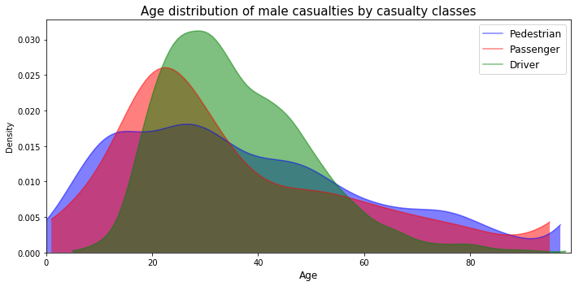

```python
#Creating male dataframe by casualty class
male_pedestrian = male_data.loc[male_data.Casualty_class == 'Pedestrian']
male_passenger = male_data.loc[male_data.Casualty_class == 'Passenger']
male_driver = male_data.loc[male_data.Casualty_class == 'Driver or rider']

#Plot density graph of age distribution of male casualties by casualty classes
ax = plt.figure(figsize=(10, 5))
sns.kdeplot(male_pedestrian.Age , color="blue", label="Pedestrian", shade = True, cut = 0, alpha=0.5)
sns.kdeplot(male_passenger.Age , color="red", label="Passenger", shade = True, cut = 0, alpha=0.5)
sns.kdeplot(male_driver.Age , color="green", label="Driver", shade = True, cut = 0, alpha=0.5)
plt.title('Age distribution of male casualties by casualty classes', fontsize = 15)
plt.xlabel('Age',fontsize = 12)
plt.ylabel('Density')

#Customise and save figure
plt.xlim(0,99)
plt.legend(fontsize= 12)
plt.tight_layout()
plt.savefig('fig4',dpi=300)
plt.show()
```

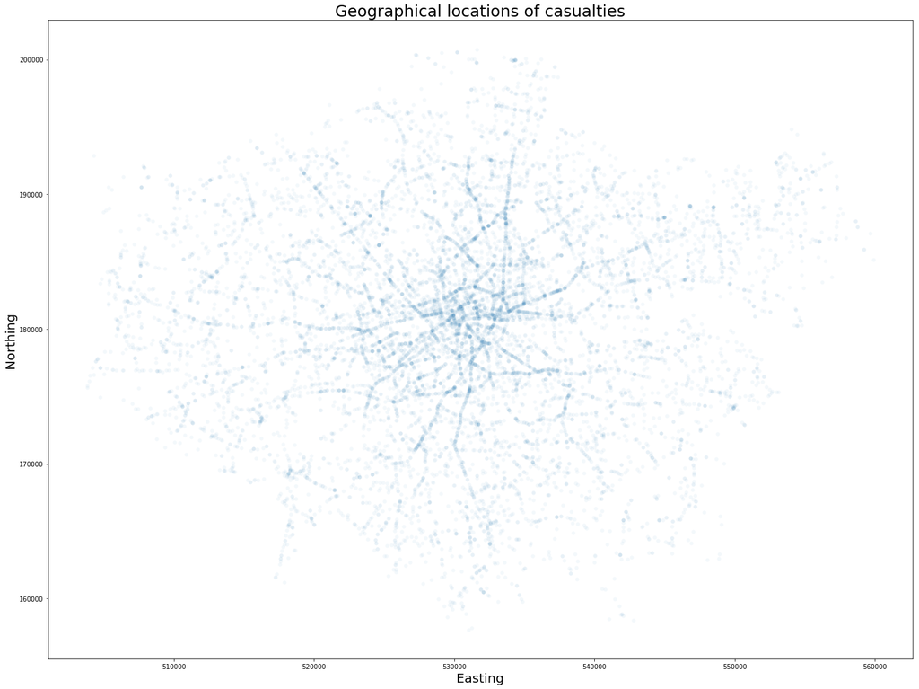

```python
#Create figure
plt.figure(figsize=(20,15))

#Plot Easting and Northing variables
sns.scatterplot(x='Easting',y='Northing',data=df1, alpha=0.05)

#Customise and save figure
plt.title('Geographical locations of casualties', fontsize = 25)
plt.xlabel('Easting',fontsize = 20)
plt.ylabel('Northing',fontsize = 20)
plt.tight_layout()
plt.savefig('fig5',dpi=300)
plt.show()
```

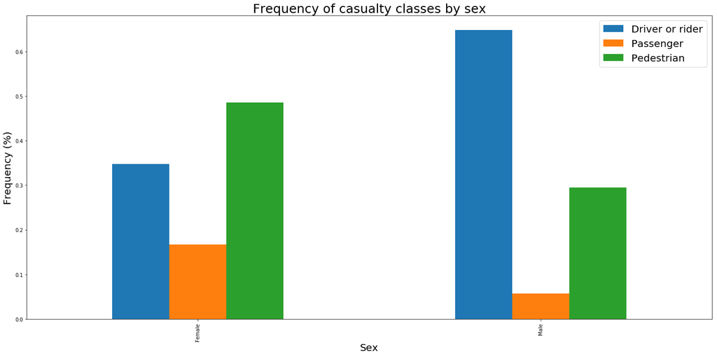

```python
#Create a table with sex and casualty class variables
table1=pd.crosstab(df1['Sex'], df1['Casualty_class']).apply(lambda r: r/r.sum(), axis=1)

#Plot the frequencies
table1.plot.bar(figsize=(20,10))

#Customize and save the plot
plt.title('Frequency of casualty classes by sex', fontsize = 25)
plt.xlabel('Sex',fontsize = 20)
plt.ylabel('Frequency (%)',fontsize = 20)
plt.legend(fontsize= 20)
plt.tight_layout()
plt.savefig('fig9',dpi=300)
plt.show()
```

The new ‘Hour_of_day’ variable is an ordinal categorical variable with the mode of ‘Evening – Peak Hour’ and the median is same, ‘Evening – Peak Hour’. A total of 3507 incidents were recorded during the evening peak hour which is between 16-19. This variable is categorized as follows:

- 5 to 7 as Morning – Before 7:30
- 8 to 10 as Morning – Peak Hour
- 11 to 15 as Midday
- 16 to 19 as Evening – Peak Hour
- 20 to 24 as Late Evening
- 0 to 4 as Night

```python
#Group hour_of_day variable to avoid messy graphs
df3 = df1.copy()
df3['Hour_of_day']=np.where(df3['Hour_of_day'] ==5, 'Morning - Before 7:30', df3['Hour_of_day'])
df3['Hour_of_day']=np.where(df3['Hour_of_day'] =='6', 'Morning - Before 7:30', df3['Hour_of_day'])
df3['Hour_of_day']=np.where(df3['Hour_of_day'] =='7', 'Morning - Before 7:30', df3['Hour_of_day'])
df3['Hour_of_day']=np.where(df3['Hour_of_day'] =='8', 'Morning - Peak Hour', df3['Hour_of_day'])
df3['Hour_of_day']=np.where(df3['Hour_of_day'] =='9', 'Morning - Peak Hour', df3['Hour_of_day'])
df3['Hour_of_day']=np.where(df3['Hour_of_day'] =='10', 'Morning - Peak Hour', df3['Hour_of_day'])
df3['Hour_of_day']=np.where(df3['Hour_of_day'] =='11', 'Midday', df3['Hour_of_day'])
df3['Hour_of_day']=np.where(df3['Hour_of_day'] =='12', 'Midday', df3['Hour_of_day'])
df3['Hour_of_day']=np.where(df3['Hour_of_day'] =='13', 'Midday', df3['Hour_of_day'])
df3['Hour_of_day']=np.where(df3['Hour_of_day'] =='14', 'Midday', df3['Hour_of_day'])
df3['Hour_of_day']=np.where(df3['Hour_of_day'] =='15', 'Midday', df3['Hour_of_day'])
df3['Hour_of_day']=np.where(df3['Hour_of_day'] =='16', 'Evening - Peak Hour', df3['Hour_of_day'])
df3['Hour_of_day']=np.where(df3['Hour_of_day'] =='17', 'Evening - Peak Hour', df3['Hour_of_day'])
df3['Hour_of_day']=np.where(df3['Hour_of_day'] =='18', 'Evening - Peak Hour', df3['Hour_of_day'])
df3['Hour_of_day']=np.where(df3['Hour_of_day'] =='19', 'Evening - Peak Hour', df3['Hour_of_day'])
df3['Hour_of_day']=np.where(df3['Hour_of_day'] =='20', 'Late Evening', df3['Hour_of_day'])
df3['Hour_of_day']=np.where(df3['Hour_of_day'] =='21', 'Late Evening', df3['Hour_of_day'])
df3['Hour_of_day']=np.where(df3['Hour_of_day'] =='22', 'Late Evening', df3['Hour_of_day'])
df3['Hour_of_day']=np.where(df3['Hour_of_day'] =='23', 'Late Evening', df3['Hour_of_day'])
df3['Hour_of_day']=np.where(df3['Hour_of_day'] =='24', 'Late Evening', df3['Hour_of_day'])
df3['Hour_of_day']=np.where(df3['Hour_of_day'] =='0', 'Night', df3['Hour_of_day'])
df3['Hour_of_day']=np.where(df3['Hour_of_day'] =='1', 'Night', df3['Hour_of_day'])
df3['Hour_of_day']=np.where(df3['Hour_of_day'] =='2', 'Night', df3['Hour_of_day'])
df3['Hour_of_day']=np.where(df3['Hour_of_day'] =='3', 'Night', df3['Hour_of_day'])
df3['Hour_of_day']=np.where(df3['Hour_of_day'] =='4', 'Night', df3['Hour_of_day'])
```

```python
#Setting data types
for i in df3.columns:
    if i=='Severity_of_casualty': #setting an ordinal variable
        Severity= ['Serious','Fatal']
        df3[i] = df3[i].astype(CategoricalDtype(categories=Severity,ordered=True))
    elif i=='Hour_of_day': #setting an ordinal variable
        Hour=['Morning - Before 7:30','Morning - Peak Hour', 'Midday', 'Evening - Peak Hour','Late Evening','Night']
        df3[i] = df3[i].astype(CategoricalDtype(categories=Hour,ordered=True))
    elif i=='Day_of_week': #setting an ordinal variable
        Day=['Monday','Tuesday','Wednesday','Thursday','Friday','Saturday','Sunday']
        df3[i] = df3[i].astype(CategoricalDtype(categories=Day,ordered=True))
    elif i=='Age' or i=='Easting' or i=='Northing':
        df3[i] = df3[i].astype('int64')
    elif i=='Date':
        df3[i] = df3[i].astype('datetime64')
    else: #setting a nominal variable
        df3[i] = df3[i].astype('category')
df3.dtypes
```

```
Easting                          int64
Northing                         int64
Severity_of_casualty          category
Casualty_class                category
Sex                           category
Age                              int64
Date                    datetime64[ns]
Day_of_week                   category
Hour_of_day                   category
Local_authority               category
Vehicle_type                  category
dtype: object
```

```python
#Plot a bar graph
df3['Hour_of_day'].value_counts().iplot(kind='bar',colors='rgb(81, 197, 247)', xTitle='Hour',yTitle='Number of casualties',
          title='Casualty frequency by Hour_of_day')
```

[interactive chart not shown]

```python
#Observe a ordinal categorical variable median
df3['Hour_of_day'].cat.codes.median()
```

```
3.0
```

```python
#https://blog.algorexhealth.com/2017/09/10-heatmaps-10-python-libraries/
#Create an interactive heatmap
heatmaptable1=pd.crosstab(df3['Day_of_week'], df3['Hour_of_day'])
colorscale = [[0, '#edf8fb'], [.2, '#b3cde3'],  [.6, '#8856a7'],  [1, '#810f7c']]
data = [go.Heatmap(z=heatmaptable1.values.tolist(), x=heatmaptable1.columns, y=heatmaptable1.index, colorscale=colorscale)]
py.iplot(data)
```

[interactive chart not shown]

```python
#Read the data but now parsing dates to create index
ts = pd.read_csv('london-ksi-only-since2010.csv', parse_dates=[['Date', 'Hour of day']],
                 infer_datetime_format=True, index_col=0)
#Rename columns
ts.columns=['Easting','Northing','Severity_of_casualty','Casualty_class','Sex','Age','Day_of_week','Local_authority','Vehicle_type','Pedestrian_locality']
#Drop Pedestrian Locality
ts=ts.drop(['Pedestrian_locality'],axis=1)
#Drop unknown age records
ts = ts[(ts.Age != 'unknown')]

#CREATE AN HOURLY INDEX
ts.index = ts.index.to_period('1H')
ts.index.name = 'time'

ts.sort_index(inplace=True);
ts.head(2)
```

| time | Easting | Northing | Severity_of_casualty | Casualty_class | Sex | Age | Day_of_week | Local_authority | Vehicle_type |
| --- | --- | --- | --- | --- | --- | --- | --- | --- | --- |
| 2010-01-01 01:00 | 526630 | 184330 | Serious | Pedestrian | Female | 56 | Friday | Camden | Car |
| 2010-01-01 04:00 | 531850 | 166510 | Serious | Pedestrian | Male | 53 | Friday | Croydon | Car |

```python
#Observe datatypes
ts.dtypes
```

```
Easting                  int64
Northing                 int64
Severity_of_casualty    object
Casualty_class          object
Sex                     object
Age                     object
Day_of_week             object
Local_authority         object
Vehicle_type            object
dtype: object
```

```python
#Setting data types
for i in ts.columns:
    if i=='Severity_of_casualty': #setting an ordinal variable
        Severity= ['Serious','Fatal']
        ts[i] = ts[i].astype(CategoricalDtype(categories=Severity,ordered=True))
    elif i=='Day_of_week': #setting an ordinal variable
        Day=['Monday','Tuesday','Wednesday','Thursday','Friday','Saturday','Sunday']
        ts[i] = ts[i].astype(CategoricalDtype(categories=Day,ordered=True))
    elif i=='Age' or i=='Easting' or i=='Northing':
        ts[i] = ts[i].astype('int64')
    else: #setting a nominal variable
        ts[i] = ts[i].astype('category')
ts.dtypes
```

```
Easting                    int64
Northing                   int64
Severity_of_casualty    category
Casualty_class          category
Sex                     category
Age                        int64
Day_of_week             category
Local_authority         category
Vehicle_type            category
dtype: object
```

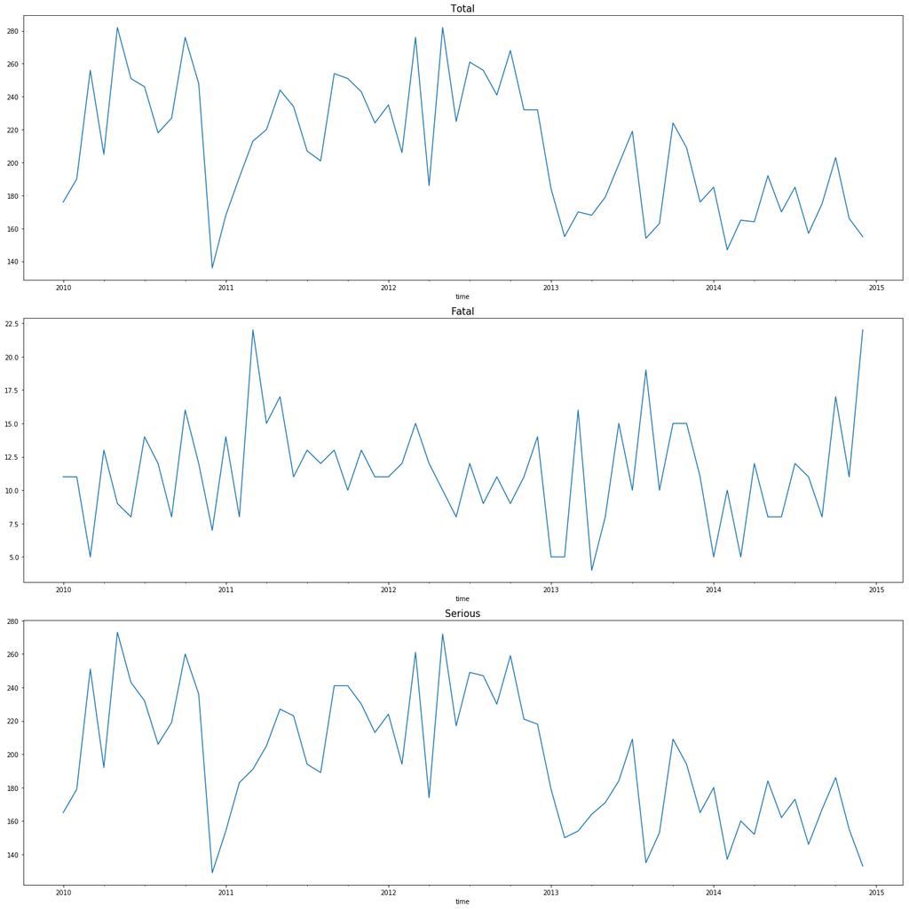

```python
#Create a figure
fig= plt.figure(figsize=(20,20))

#Plot total monthly frequencies by year
fig.add_subplot(3,1,1)
total_monthly = ts.resample('1M').size()
ax = total_monthly.plot()
ax.set_title("Total",fontsize=15)

#Plot fatal monthly frequencies by year
fig.add_subplot(3,1,2)
fatal = ts.loc[ts['Severity_of_casualty'] == 'Fatal']
fatal_monthly = fatal.resample('1M').size()
ax = fatal_monthly.plot()
ax.set_title("Fatal",fontsize=15)

#Plot serious monthly frequencies by year
fig.add_subplot(3,1,3)
serious = ts.loc[ts['Severity_of_casualty'] == 'Serious']
serious_monthly = serious.resample('1M').size()
ax = serious_monthly.plot()
ax.set_title("Serious",fontsize=15)

#Customise and save figure
plt.tight_layout()
plt.savefig('fig6',dpi=300)
plt.show()
```

```python
#Observe montly frequencies
total_monthly.sort_values(axis=0, ascending=False)
```

```
time
2010-05    282
2012-05    282
2010-10    276
2012-03    276
2012-10    268
2012-07    261
2010-03    256
2012-08    256
2011-09    254
2011-10    251
2010-06    251
2010-11    248
2010-07    246
2011-05    244
2011-11    243
2012-09    241
2012-01    235
2011-06    234
2012-11    232
2012-12    232
2010-09    227
2012-06    225
2011-12    224
2013-10    224
2011-04    220
2013-07    219
2010-08    218
2011-03    213
2013-11    209
2011-07    207
2012-02    206
2010-04    205
2014-10    203
2011-08    201
2013-06    199
2014-05    192
2011-02    191
2010-02    190
2012-04    186
2014-07    185
2014-01    185
2013-01    184
2013-05    179
2010-01    176
2013-12    176
2014-09    175
2013-03    170
2014-06    170
2011-01    168
2013-04    168
2014-11    166
2014-03    165
2014-04    164
2013-09    163
2014-08    157
2013-02    155
2014-12    155
2013-08    154
2014-02    147
2010-12    136
Freq: M, dtype: int64
```

```python
#Observe monthly frequencies
fatal_monthly.sort_values(axis=0, ascending=False)
```

```
time
2014-12    22
2011-03    22
2013-08    19
2014-10    17
2011-05    17
2013-03    16
2010-10    16
2013-06    15
2013-10    15
2013-11    15
2011-04    15
2012-03    15
2010-07    14
2012-12    14
2011-01    14
2010-04    13
2011-07    13
2011-09    13
2011-11    13
2012-04    12
2010-08    12
2014-07    12
2010-11    12
2011-08    12
2014-04    12
2012-02    12
2012-07    12
2011-06    11
2011-12    11
2012-01    11
2010-02    11
2010-01    11
2014-08    11
2014-11    11
2012-09    11
2013-12    11
2012-11    11
2012-05    10
2013-09    10
2013-07    10
2014-02    10
2011-10    10
2012-10     9
2012-08     9
2010-05     9
2010-09     8
2010-06     8
2014-09     8
2014-06     8
2014-05     8
2011-02     8
2013-05     8
2012-06     8
2010-12     7
2014-03     5
2014-01     5
2013-02     5
2010-03     5
2013-01     5
2013-04     4
Freq: M, dtype: int64
```

```python
#Observe monthly frequencies
serious_monthly.sort_values(axis=0, ascending=False)
```

```
time
2010-05    273
2012-05    272
2012-03    261
2010-10    260
2012-10    259
2010-03    251
2012-07    249
2012-08    247
2010-06    243
2011-10    241
2011-09    241
2010-11    236
2010-07    232
2011-11    230
2012-09    230
2011-05    227
2012-01    224
2011-06    223
2012-11    221
2010-09    219
2012-12    218
2012-06    217
2011-12    213
2013-07    209
2013-10    209
2010-08    206
2011-04    205
2012-02    194
2011-07    194
2013-11    194
2010-04    192
2011-03    191
2011-08    189
2014-10    186
2014-05    184
2013-06    184
2011-02    183
2014-01    180
2013-01    179
2010-02    179
2012-04    174
2014-07    173
2013-05    171
2014-09    167
2010-01    165
2013-12    165
2013-04    164
2014-06    162
2014-03    160
2014-11    155
2011-01    154
2013-03    154
2013-09    153
2014-04    152
2013-02    150
2014-08    146
2014-02    137
2013-08    135
2014-12    133
2010-12    129
Freq: M, dtype: int64
```

```python
#Observe statistics
display(total_monthly.describe())
display(fatal_monthly.describe())
display(serious_monthly.describe())
```

```
count     60.000000
mean     208.750000
std       38.751107
min      136.000000
25%      175.750000
50%      206.500000
75%      241.500000
max      282.000000
dtype: float64
```

```
count    60.000000
mean     11.350000
std       3.874405
min       4.000000
25%       8.750000
50%      11.000000
75%      13.250000
max      22.000000
dtype: float64
```

```
count     60.000000
mean     197.400000
std       38.572055
min      129.000000
25%      165.000000
50%      193.000000
75%      227.750000
max      273.000000
dtype: float64
```

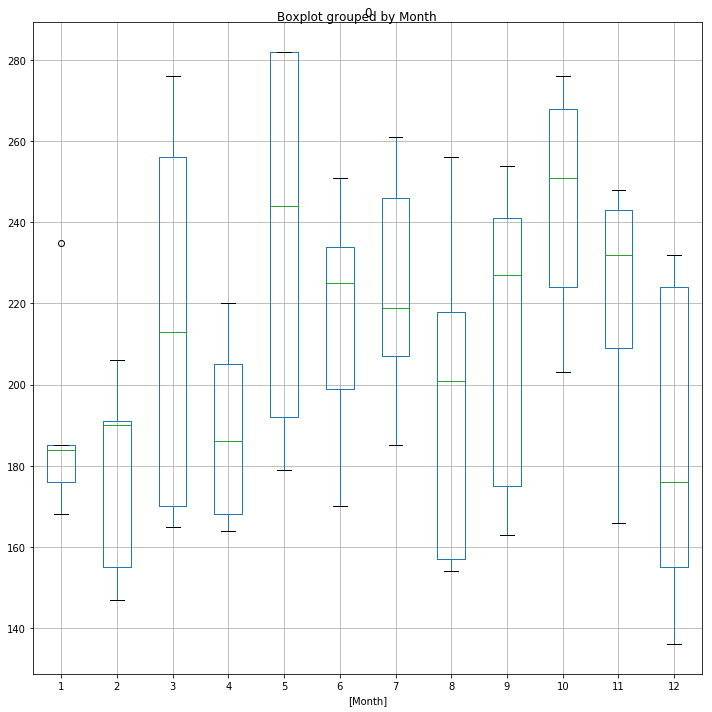

```python
#Create a boxplot grouped by month to observe seasonality
ts_seasonal = ts.resample('1M').size().to_frame()
ts_seasonal['Month'] = ts_seasonal.index.month
ts_seasonal.reset_index(inplace=True, drop=True)
ts_seasonal.boxplot(by='Month',figsize=(10,10))

#Customise and save the figure
plt.tight_layout()
plt.savefig('fig7',dpi=300)
plt.show()
```

```python
#Read the data
ts1 = pd.read_csv('london-ksi-only-since2010.csv', parse_dates=[['Date', 'Hour of day']],
                 infer_datetime_format=True, index_col=0)
#Rename the columns
ts1.columns=['Easting','Northing','Severity_of_casualty','Casualty_class','Sex','Age','Day_of_week','Local_authority','Vehicle_type','Pedestrian_locality']
#Drop column
ts1=ts1.drop(['Pedestrian_locality'],axis=1)
#Drop rows containing unknown age
ts1 = ts1[(ts1.Age != 'unknown')]

#CREATE YEARLY INDEX
ts1.index = ts1.index.to_period('1Y')
ts1.index.name = 'time'
ts1.sort_index(inplace=True);

#CREATE A NEW COLUMN
ts1['Year']=ts1.index
ts1.head(2)
```

| time | Easting | Northing | Severity_of_casualty | Casualty_class | Sex | Age | Day_of_week | Local_authority | Vehicle_type | Year |
| --- | --- | --- | --- | --- | --- | --- | --- | --- | --- | --- |
| 2010 | 526940 | 177890 | Serious | Pedestrian | Male | 14 | Friday | Kensington and Chelsea | Motorcycle over 125cc and up to 500cc | 2010 |
| 2010 | 527790 | 179400 | Serious | Pedestrian | Female | 46 | Wednesday | Kensington and Chelsea | Taxi/Private hire car | 2010 |

```python
#Create an interactive bar chart to observe casualty frequency by year
ts1['Year'].value_counts().iplot(kind='bar',colors='rgb(244, 104, 66)', xTitle='Year',yTitle='Number of casualties',
          title='Casualty frequency by Year')
```

[interactive chart not shown]

## Results

There were three main research questions throughout the project. They can be listed as follows:

- Are there specific locations prone to casualties?
- Are there specific time periods prone to casualties?
- Are there specific demographic groups prone to casualties?

Without a deeper study and analysis consisting multidisciplinary studies and multiple datasets, it will be wrong and misleading to give definite answers to these questions. However, the insight gained from the dataset cannot be overseen.

Through univariate analysis, it is observed that with 55.7% of frequency, drivers are more likely to involve in casualties. In addition, male frequency in casualties was significantly higher than female frequency with the percentage of 69.9%. Further, it is recognized that young people regardless of their sex are getting involved in casualties more than older people. However, it is noted that older women as pedestrians are more likely to get affected by casualties. These factors can be considered as demographics of people involved in casualties and may encourage the audience at issue to take some precautions and be more careful.

In addition to demographic groups, it is noticed that more populated locations such as inner boroughs (e.g. Westminster, Lambeth, etc.) have the highest frequencies of casualties. This finding can promote the need of precautions to be taken in specific locations (e.g. crowded streets, dangerous junctions, etc.).

Moreover, in terms of time, it is detected that highest number of casualties take place at 17:00, 18:00 and 08:00 which are basically corresponding to peak hours. One of the most accidents took place on Friday peak hours which is an indicator of people on the roads should be more careful regardless of other factors. In addition, it is noted that casualties at weekends happen mostly between 20:00-04:00 which can also be considered as something to keep in mind for the people go out on weekend nights.

In conclusion, this dataset was really good at pointing some indicators of casualties. However, further work can be done by using street level but not just local authorities in order to detect problematic locations and promote the need of precautions to be taken.